# Assignment Chapter 5

Briana Cervantes

10/26/2021

### Risk and Crime

#### 1. A map of your outcome of interest in point form, with some description of what, when, and why you think selection bias may be an issue.

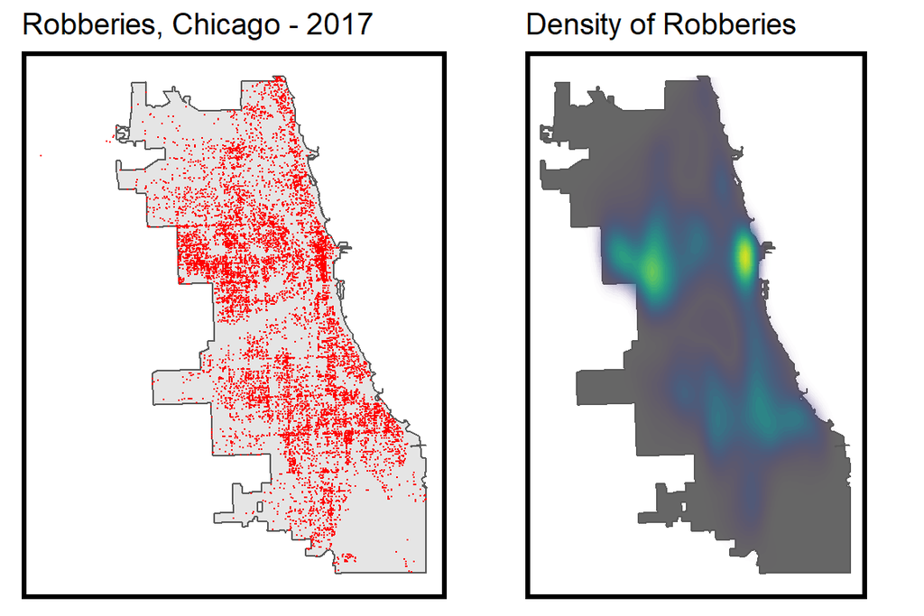

```r
# uses grid.arrange to organize indpendent plots
grid.arrange(ncol=2,
ggplot() +
  geom_sf(data = chicagoBoundary) +
  geom_sf(data = robbery, colour="red", size=0.1, show.legend = "point") +
  labs(title= "Robberies, Chicago - 2017") +
  mapTheme(title_size = 14),

ggplot() +
  geom_sf(data = chicagoBoundary, fill = "grey40") +
  stat_density2d(data = data.frame(st_coordinates(robbery)),
                 aes(X, Y, fill = ..level.., alpha = ..level..),
                 size = 0.01, bins = 40, geom = 'polygon') +
  scale_fill_viridis() +
  scale_alpha(range = c(0.00, 0.35), guide = FALSE) +
  labs(title = "Density of Robberies") +
  mapTheme(title_size = 14) + theme(legend.position = "none"))
```

Robberies in Chicago do appear to be clustered, and may, as a result, suffer from spatial bias. In other words, the amount of robberies reported may be a function of where there are cops available to take reports. Like data on other types of crime, this robbery data is not a complete sample. Generally, crimes are reported after they’ve taken place, though there are exceptions. That means this data of robberies reported are likely a function of the time and interest a victim has in pursuing a report, or if a police officer or other authority witnessed it happening. It may be easier to report a crime to a police officer nearby rather than calling 911 and waiting for a cop to show. Thus, the clustering we see on these first maps may be a product of where police are accessible to the public. This factor, of police presence, can be a result of the time of day the robbery happens or whether police beats are nearby.

#### 2. A map of your outcome joined to the fishnet.

```r
fishnet <-
  st_make_grid(chicagoBoundary,
               cellsize = 500,
               square = TRUE) %>%
  .[chicagoBoundary] %>%            # <- MDH Added
  st_sf() %>%
  mutate(uniqueID = rownames(.))

crime_net <-
  dplyr::select(robbery) %>%
  mutate(countRobberies = 1) %>%
 aggregate(., fishnet, sum) %>%
  mutate(countRobberies = replace_na(countRobberies, 0),
         uniqueID = rownames(.),
         cvID = sample(round(nrow(fishnet) / 24),
                       size=nrow(fishnet), replace = TRUE))
```

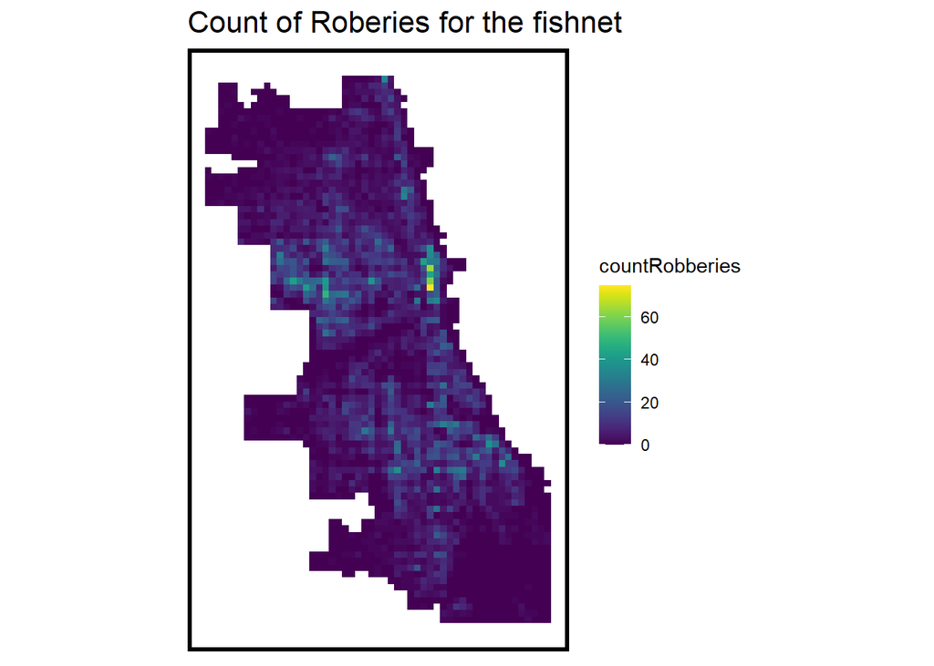

#### 3. A small multiple map of your risk factors in the fishnet (counts, distance and/or other feature engineering approaches).

```r
    ## Abandoned Cars
abandonCars <-
  read.socrata("https://data.cityofchicago.org/Service-Requests/311-Service-Requests-Abandoned-Vehicles/3c9v-pnva") %>%
    mutate(year = substr(creation_date,1,4)) %>% filter(year == "2017") %>%
    dplyr::select(Y = latitude, X = longitude) %>%
    na.omit() %>%
    st_as_sf(coords = c("X", "Y"), crs = 4326, agr = "constant") %>%
    st_transform(st_crs(fishnet)) %>%
    mutate(Legend = "Abandoned_Cars")




abandonCars <- abandonCars %>%
    mutate(Legend = "Abandoned_Cars")%>%dplyr::select(Legend)

liquor.fish <- liquor %>%
    st_transform(st_crs(fishnet)) %>%
    mutate(Legend = "liquor.licenses")%>%dplyr::select(Legend)

Lstops.sf <- Lstops.sf %>%
    st_transform(st_crs(fishnet)) %>%
    mutate(Legend = "Lstops")%>%dplyr::select(Legend)


busstops.sf <- busstops %>%
    st_transform(st_crs(fishnet)) %>%
    mutate(Legend = "bus_stops")%>%dplyr::select(Legend)

## Neighborhoods to use in LOOCV in a bit
neighborhoods <-
  st_read("https://raw.githubusercontent.com/blackmad/neighborhoods/master/chicago.geojson") %>%
  st_transform(st_crs(fishnet))

vars_net <-
  rbind(abandonCars, liquor.fish,busstops.sf, Lstops.sf) %>%
  st_join(., fishnet, join=st_within) %>%
  st_drop_geometry() %>%
  group_by(uniqueID, Legend) %>%
  summarize(count = n()) %>%
    full_join(fishnet) %>%
    spread(Legend, count, fill=0) %>%
    st_sf() %>%
    dplyr::select(-`<NA>`) %>%
    na.omit() %>%
    ungroup()


#### NN

# convinience to reduce length of function names.
st_c    <- st_coordinates
st_coid <- st_centroid


vars_net <- vars_net %>%
    mutate(busStops.nn = nn_function(st_c(st_coid(vars_net)),
                                           st_c(busstops.sf),
                                           k = 5)) %>%
    mutate(Lstops.nn = nn_function(st_c(st_coid(vars_net)),
                                           st_c(Lstops.sf),
                                           k = 5)) %>%
    mutate(liquor.nn = nn_function(st_c(st_coid(vars_net)),
                                           st_c(liquor.fish),
                                           k = 5))%>%
    mutate(abandonedcars.nn = nn_function(st_c(st_coid(vars_net)),
                                           st_c(abandonCars),
                                           k = 5))



#### Visualizing Prep


vars_net.long.nn <-
  dplyr::select(vars_net, ends_with(".nn")) %>%
    gather(Variable, value, -geometry)
```

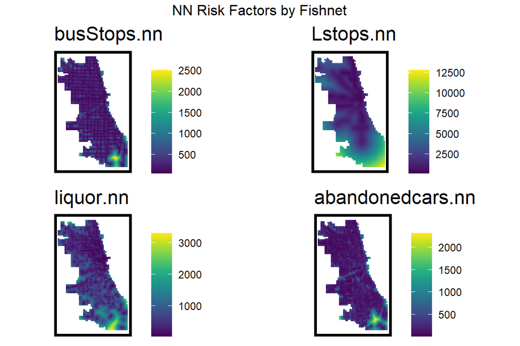

#### 4. Local Moran’s I-related small multiple map of your outcome (see 5.4.1)

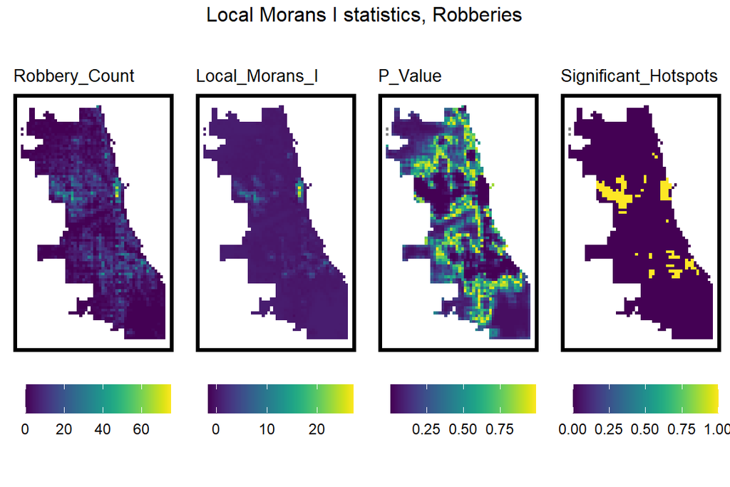

```r
### FINALE NETS

final_net <-
  left_join(crime_net, st_drop_geometry(vars_net), by="uniqueID")


###

final_net <-
  st_centroid(final_net) %>%
    st_join(dplyr::select(neighborhoods, name), by = "uniqueID") %>%
    st_join(dplyr::select(policeDistricts, District), by = "uniqueID") %>%
      st_drop_geometry() %>%
      left_join(dplyr::select(final_net, geometry, uniqueID)) %>%
      st_sf() %>%
  na.omit()


#### Weights

## generates warnings from PROJ issues
## {spdep} to make polygon to neighborhoods...

final_net.nb <- poly2nb(as_Spatial(final_net), queen=TRUE)

## ... and neighborhoods to list of weigths


final_net.weights <- nb2listw(final_net.nb , style="W", zero.policy=TRUE)



## see ?localmoran
local_morans <- localmoran(final_net$countRobberies, final_net.weights, zero.policy=TRUE) %>%
  as.data.frame()


# join local Moran's I results to fishnet
final_net.localMorans <-
  cbind(local_morans, as.data.frame(final_net)) %>%
  st_sf() %>%
  dplyr::select(Robbery_Count = countRobberies,
                Local_Morans_I = Ii,
                P_Value = `Pr(z != E(Ii))`) %>%
  mutate(Significant_Hotspots = ifelse(P_Value <= 0.001, 1, 0)) %>%
  gather(Variable, Value, -geometry)



#### PREP THE PLOTS


vars.moran <- unique(final_net.localMorans$Variable)
varList <- list()
```

#### 5. A small multiple scatter plot with correlations.

```r
final_net <- final_net %>%
  mutate(robberies.isSig =
           ifelse(local_morans[,5] <= 0.001, 1, 0)) %>%
  mutate(robberies.isSig.dist =
           nn_function(st_c(st_coid(final_net)),
                       st_c(st_coid(filter(final_net,
                                           robberies.isSig == 1))),
                       k = 1))
```

```r
#### for counts
correlation.long <-
  st_drop_geometry(final_net) %>%
    dplyr::select(-uniqueID, -cvID,  -name, -District) %>%
    gather(Variable, Value, -countRobberies)



 ##### for nn

correlation.cor <-
  correlation.long %>%
    group_by(Variable) %>%
    summarize(correlation = cor(Value, countRobberies, use = "complete.obs"))
```

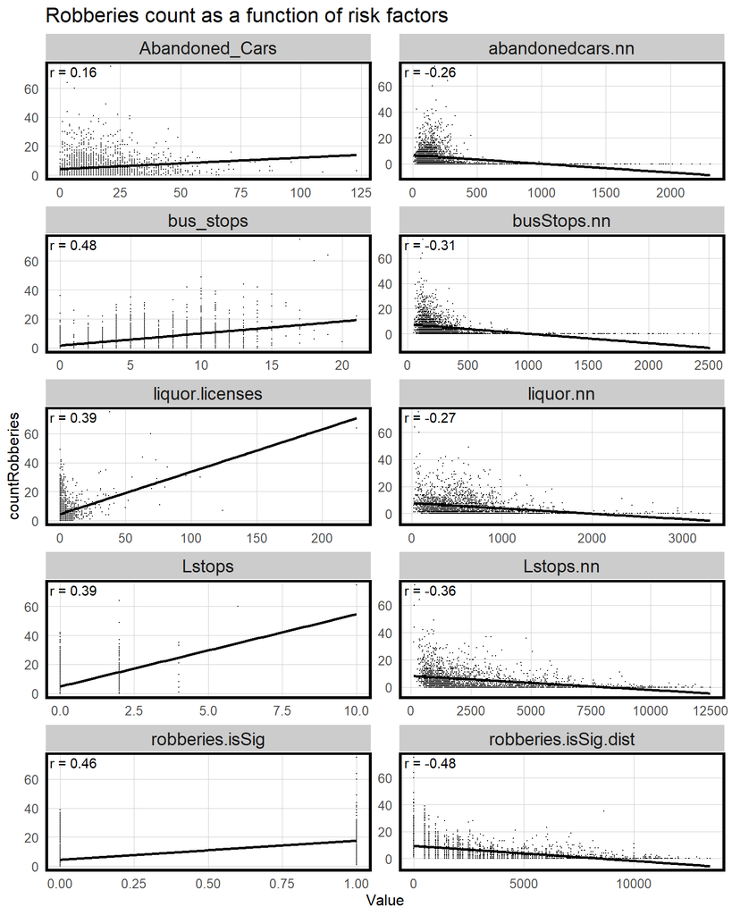

#### 6. Histogram of your dependent variable.

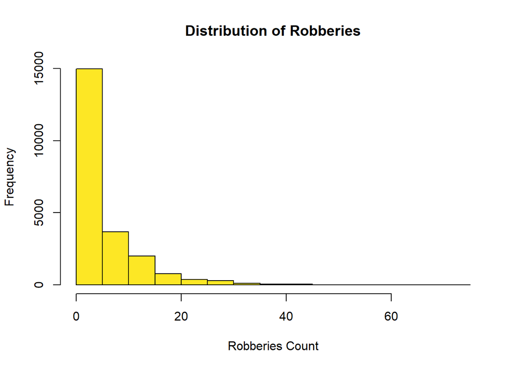

#### 7. A small multiple map of model errors by random k-fold and spatial cross validation.

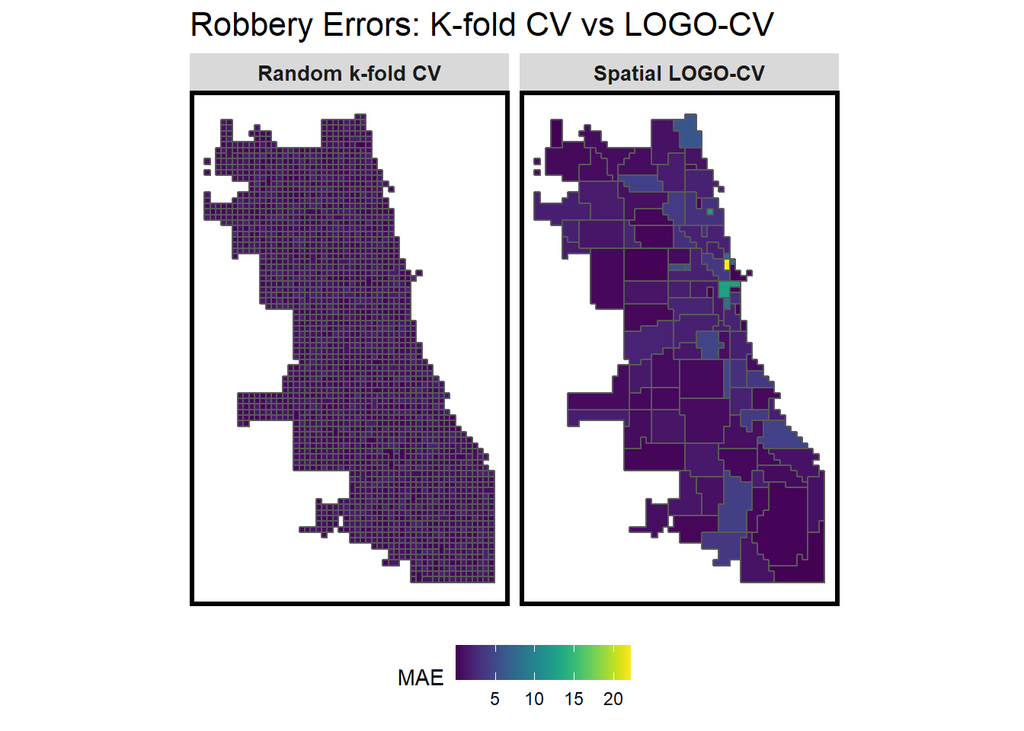

```r
colnames(final_net)
# View(crossValidate)

## define the variables we want
reg.ss.vars <- c("abandonedcars.nn", "liquor.nn", "Lstops.nn", "busStops.nn", "robberies.isSig", "robberies.isSig.dist" )

## RUN REGRESSIONS

#### K-fold
reg.ss.Kfold.spatialCV <- crossValidate2(
  dataset = final_net,
  id = "cvID",
  dependentVariable = "countRobberies",
  indVariables = reg.ss.vars) %>%
    dplyr::select(cvID, countRobberies, Prediction, geometry)

#### Spatial LOGO-CV: Spatial Process
reg.ss.LOGO.spatialCV <- crossValidate2(
  dataset = final_net,
  id = "name",
  dependentVariable = "countRobberies",
  indVariables = reg.ss.vars) %>%
    dplyr::select(cvID = name, countRobberies, Prediction, geometry)



#### bind

reg.summary <-
  rbind(
    mutate(reg.ss.Kfold.spatialCV,        Error = Prediction - countRobberies,
                             Regression = "Random k-fold CV"),
     mutate(reg.ss.LOGO.spatialCV, Error = Prediction - countRobberies,
                             Regression = "Spatial LOGO-CV")) %>%
    st_sf()




# calculate errors by NEIGHBORHOOD
error_by_reg_and_fold <-
  reg.summary  %>%
    group_by(Regression, cvID) %>%
    summarize(Mean_Error = mean(Prediction - countRobberies, na.rm = T),
              MAE = mean(abs(Mean_Error), na.rm = T),
              SD_MAE = mean(abs(Mean_Error), na.rm = T)) %>%
  ungroup()
error_by_reg_and_fold %>%
  arrange(desc(MAE))
error_by_reg_and_fold %>%
  arrange(MAE)
```

The corresponding histogram below, helped me understand the difference in the MAE, so I included it.

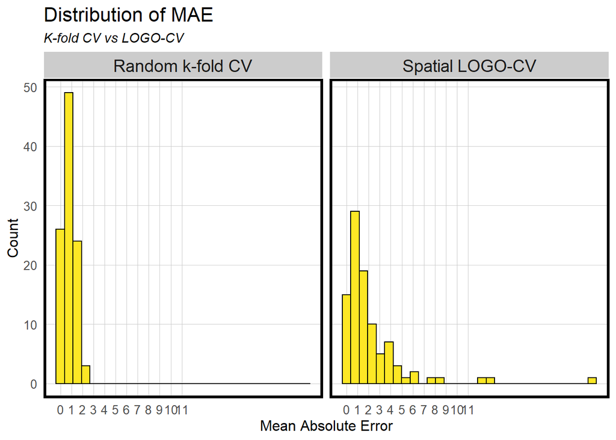

#### 8. A table of MAE and standard deviation MAE by regression.

```r
st_drop_geometry(error_by_reg_and_fold) %>%
  group_by(Regression) %>%
    summarize(Mean_MAE = round(mean(MAE), 2),
              SD_MAE = round(sd(MAE), 2)) %>%
  kable() %>%
    kable_styling(full_width = FALSE)
```

| Regression | Mean_MAE | SD_MAE |
| --- | --- | --- |
| Random k-fold CV | 0.83 | 0.55 |
| Spatial LOGO-CV | 2.17 | 3.06 |

#### 9. A table of raw errors by race context for a random k-fold vs. spatial cross validation regression.

```r
tracts18 <-
  get_acs(geography = "tract", variables = c("B01001_001E","B01001A_001E"),
          year = 2018, state=17, county=031, geometry=T) %>%
  st_transform('ESRI:102271')  %>%
  dplyr::select(variable, estimate, GEOID) %>%
  spread(variable, estimate) %>%
  rename(TotalPop = B01001_001,
         NumberWhites = B01001A_001) %>%
  mutate(percentWhite = NumberWhites / TotalPop,
         raceContext = ifelse(percentWhite > .5, "Majority_White", "Majority_Non_White")) %>%
  .[neighborhoods,]
```

Mean Error by neighborhood racial context

| Regression | Majority_Non_White | Majority_White |
| --- | --- | --- |
| Random k-fold CV | -0.5454472 | 0.5629870 |
| Spatial LOGO-CV | -0.5840954 | 0.5829368 |

#### 10. The map comparing kernel density to risk predictions for the next year’s crime.

```r
#The `spatstat` function gets us kernal density estimates with varying search radii.

#Note that the code here is *different* than in the book - it has been updated to keep up with changes in #packages.

#### NExt year's crime

robbery18 <-
  read.socrata("https://data.cityofchicago.org/Public-Safety/Crimes-2018/3i3m-jwuy") %>%
    filter(Primary.Type == "ROBBERY") %>%
    mutate(x = gsub("[()]", "", Location)) %>%
    separate(x,into= c("Y","X"), sep=",") %>%
    mutate(X = as.numeric(X),Y = as.numeric(Y)) %>%
    na.omit() %>%
    st_as_sf(coords = c("X", "Y"), crs = 4326, agr = "constant")%>%
    st_transform('ESRI:102271') %>%
    distinct()%>%
  .[fishnet,]




# demo of kernel width
burg_ppp <- as.ppp(st_coordinates(robbery), W = st_bbox(final_net))

burg_KD.1000 <- spatstat.core::density.ppp(burg_ppp, 1000)


#### FOR KNOWN DATA

rob_KDE_sf <- as.data.frame(burg_KD.1000) %>%
  st_as_sf(coords = c("x", "y"), crs = st_crs(final_net)) %>%
  aggregate(., final_net, mean) %>%
  mutate(label = "Kernel Density",
         Risk_Category = ntile(value, 100),
         Risk_Category = case_when(
           Risk_Category >= 90 ~ "90% to 100%",
           Risk_Category >= 70 & Risk_Category <= 89 ~ "70% to 89%",
           Risk_Category >= 50 & Risk_Category <= 69 ~ "50% to 69%",
           Risk_Category >= 30 & Risk_Category <= 49 ~ "30% to 49%",
           Risk_Category >= 1 & Risk_Category <= 29 ~ "1% to 29%")) %>%
  cbind(
    aggregate(
      dplyr::select(robbery18) %>% mutate(robCount = 1), ., sum) %>%
    mutate(robCount = replace_na(robCount, 0))) %>%
  dplyr::select(label, Risk_Category, robCount)

#### FOR PREDICTIONS
rob_risk_sf <-
  filter(reg.summary, Regression == "Spatial LOGO-CV") %>%
  mutate(label = "Risk Predictions",
         Risk_Category = ntile(Prediction, 100),
         Risk_Category = case_when(
           Risk_Category >= 90 ~ "90% to 100%",
           Risk_Category >= 70 & Risk_Category <= 89 ~ "70% to 89%",
           Risk_Category >= 50 & Risk_Category <= 69 ~ "50% to 69%",
           Risk_Category >= 30 & Risk_Category <= 49 ~ "30% to 49%",
           Risk_Category >= 1 & Risk_Category <= 29 ~ "1% to 29%")) %>%
  cbind(
    aggregate(
      dplyr::select(robbery18) %>% mutate(robCount = 1), ., sum) %>%
      mutate(robCount = replace_na(robCount, 0))) %>%
  dplyr::select(label,Risk_Category, robCount)
```

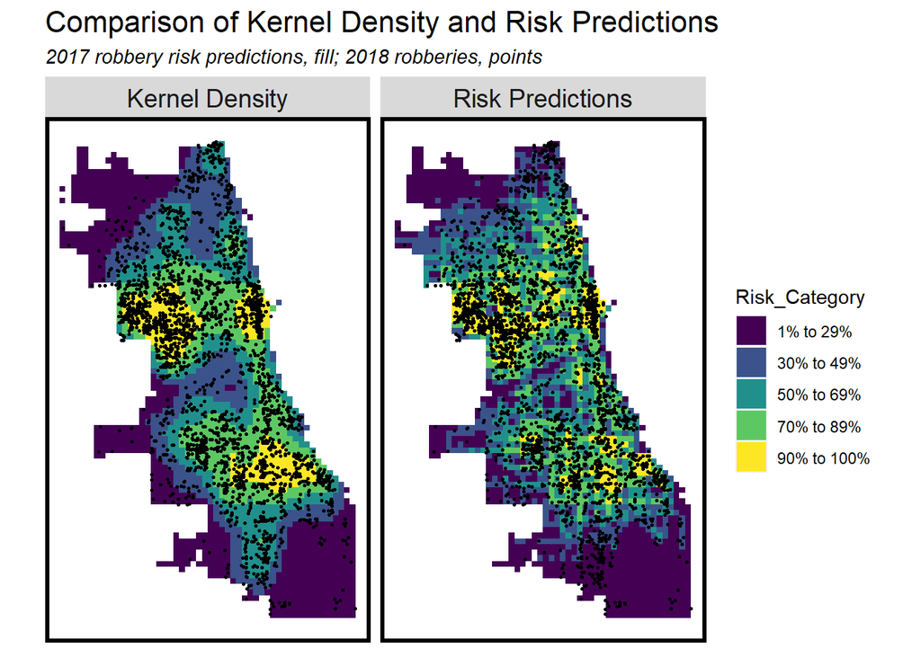

#### 11. The bar plot making this comparison.

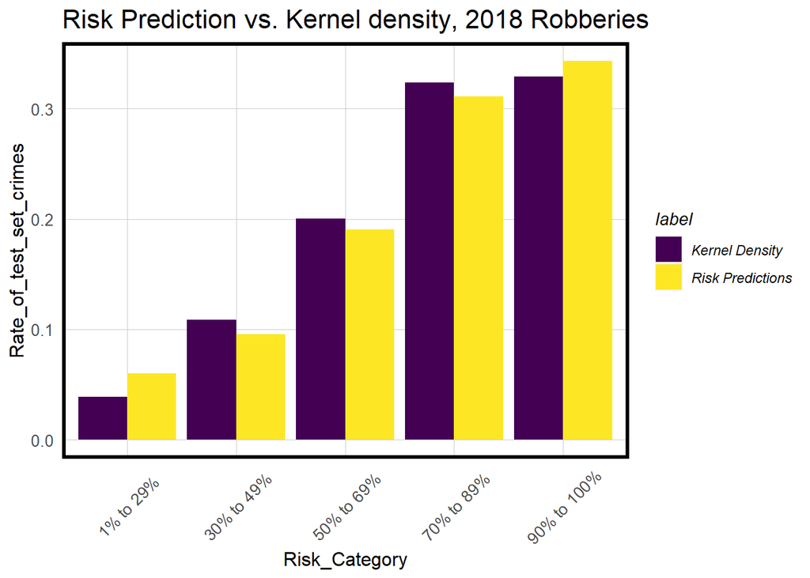

```r
rbind(rob_KDE_sf, rob_risk_sf) %>%
  st_set_geometry(NULL) %>% na.omit() %>%
  gather(Variable, Value, -label, -Risk_Category) %>%
  group_by(label, Risk_Category) %>%
  summarize(countRobberies = sum(Value))%>%
  ungroup() %>%
  group_by(label) %>%
  mutate(Rate_of_test_set_crimes = countRobberies / sum(countRobberies)) %>%
    ggplot(aes(Risk_Category,Rate_of_test_set_crimes)) +
      geom_bar(aes(fill=label), position="dodge", stat="identity") +
      scale_fill_viridis(discrete = TRUE) +
      labs(title = "Risk Prediction vs. Kernel density, 2018 Robberies") +
      plotTheme() + theme(axis.text.x = element_text(angle = 45, vjust = 0.5))
```